# The Unit Circle and Solar Engineering

## The Unit Circle

#### Create a sequence from 0 to 2 pi.

#### R trigonometric functions expect a radian argument.

```r
a = seq(0, 2*pi, length.out=1000)
```

#### Graphs of the R trigonometric functions

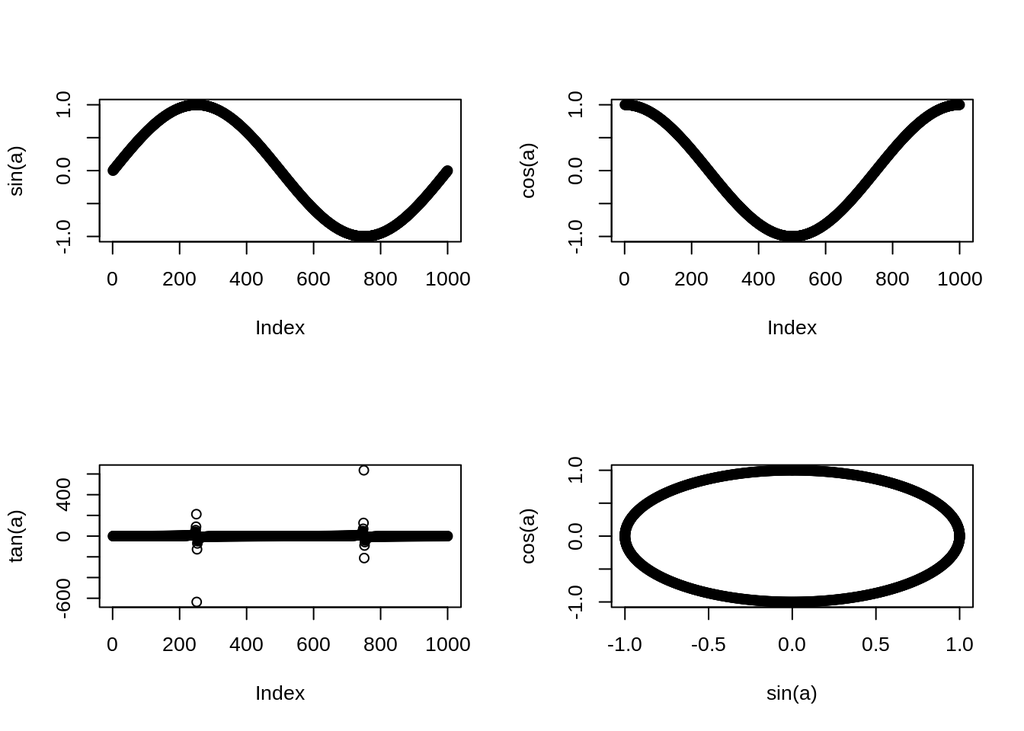

```r
par(mfrow = c(2, 2))
plot(sin(a))
plot(cos(a))
plot(tan(a))
plot(sin(a), cos(a))
```

#### This one is like $x^2 + y^2 = 1$, another representation of the unit circle.

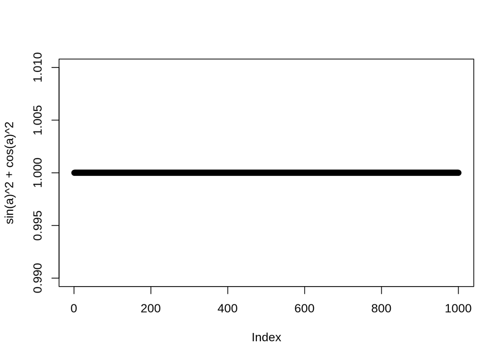

```r
plot(sin(a)^2 + cos(a)^2)
```

#### Something more complex?

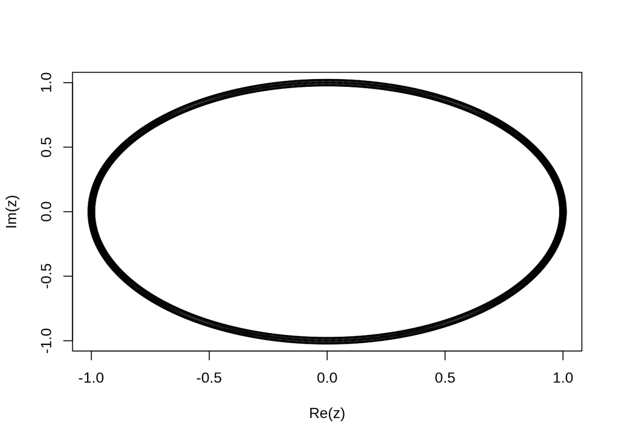

```r
z = cos(a) + complex(r = 0, i = 1)*sin(a)
plot(z)
```

#### More sums and products with trigonometric functions

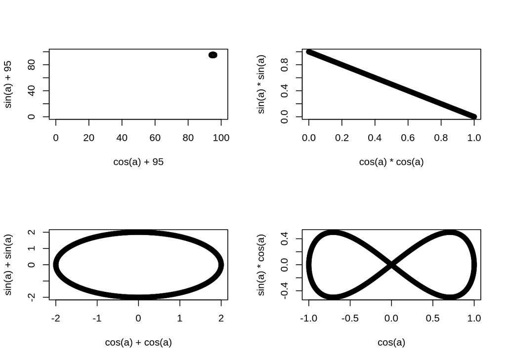

```r
par(mfrow= c(2, 2))
plot(cos(a) + 95, sin(a) + 95, xlim=c(0,100), ylim=c(0, 100))
plot(cos(a) * cos(a), sin(a) * sin(a))
plot(cos(a) + cos(a), sin(a) + sin(a))
plot(cos(a), sin(a) * cos(a))
```

## Solar Energy Science

#### Make two conversion functions: to go between radians and degrees.

```r
rad = function(x) {
  x*0.01745329
}

unrad = function(x) {
  x/0.01745329
}
```

#### Calculate the declination of the Earth (delta) using n for number of days since January 1.

#### Declination is the angle of deviation of the sun from directly above the equater casued by the combination of the 23.45 degree tilt in Earth’s polar axis and the orbit of the Earth about the sun.

##### Changed n to nn, giving 24 counts of each day and 8760 in total, i.e. hours in a year.

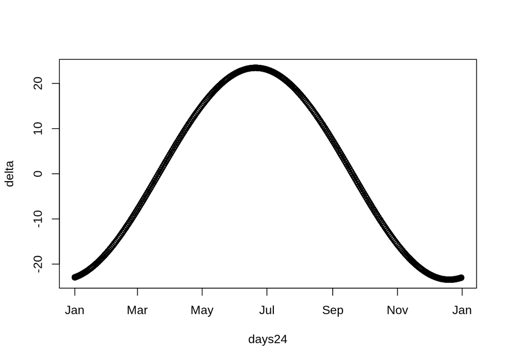

```r
n = seq(1, 365, by = 1)
nn = rep(n, 24)
nn = nn[order(nn)]

delta = 23.45*sin(rad((360/365)*(nn - 80)))

jan1 = "2019-01-01"
dec31 = "2019-12-31"
days = seq(as.Date(jan1), as.Date(dec31), by = 1)
days24 = rep(days, 24)
days24 = days24[order(days24)]

plot(days24, delta)
```

#### Define Earth Model parameters

```r
#### Approximate Davis Lattitude

phi = 38.54
```

#### We want to calculate the angle of the sunrise in Davis, given out latitude and all of Earth’s declinations

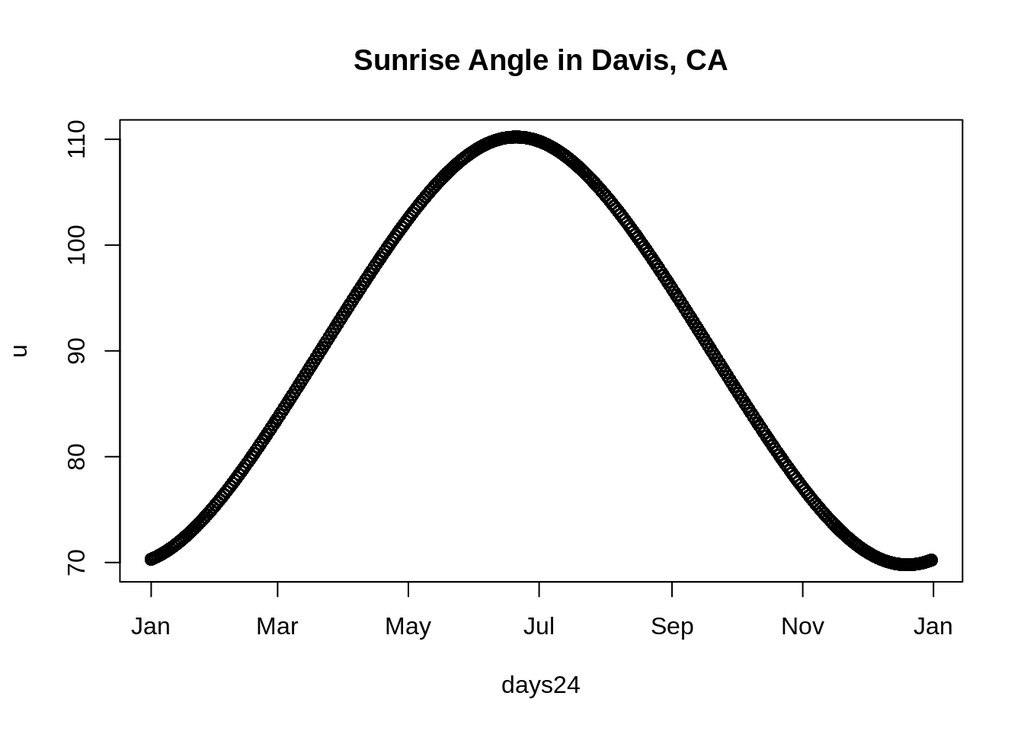

```r
o = acos(-tan(rad(phi))*tan(rad(delta)))
u = unrad(o)
plot(days24, u, main="Sunrise Angle in Davis, CA")
```

#### And now the number of sunlight hours in Davis, CA

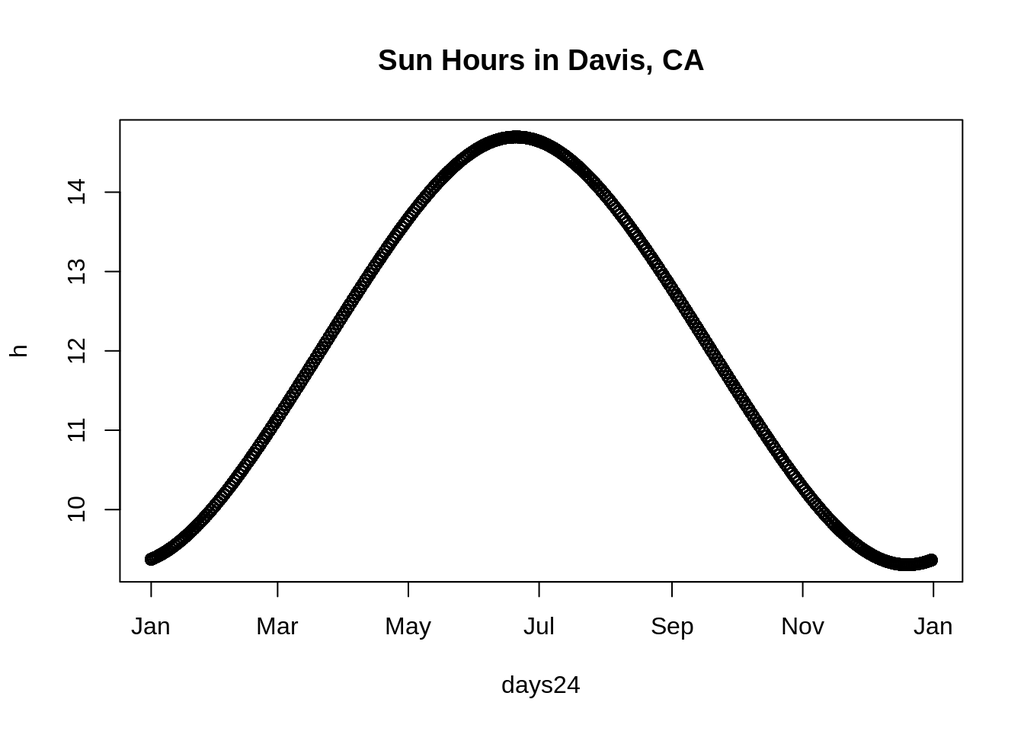

```r
h = (2/15)*u
plot(days24, h, main="Sun Hours in Davis, CA")
```

#### Can we compare to Kigali Rwanda?

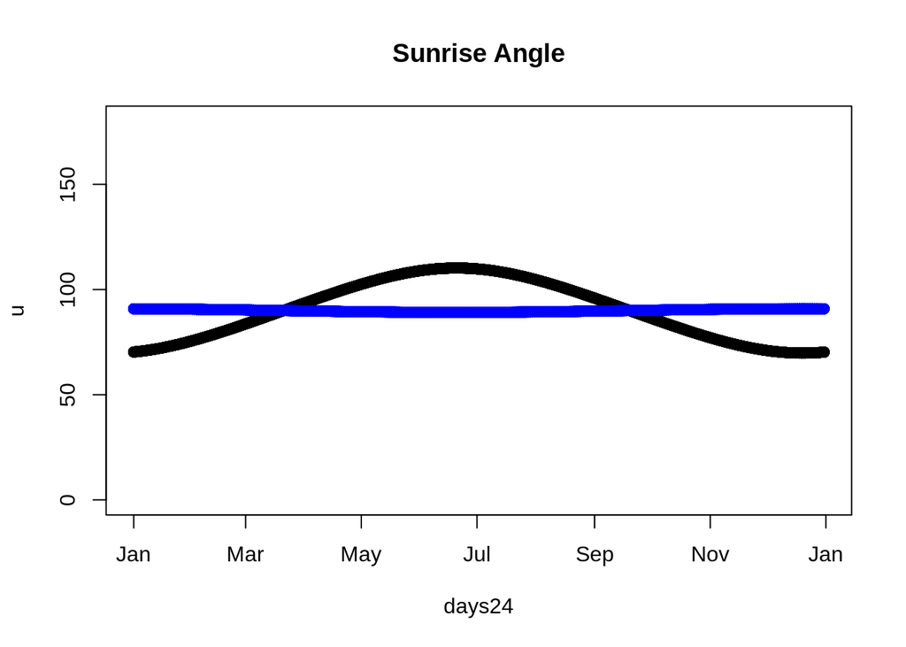

```r
phi2 = -2

o2 = acos(-tan(rad(phi2))*tan(rad(delta)))
u2 = unrad(o2)
h2 = (2/15)*u2

plot(days24, u, main="Sunrise Angle", ylim=c(0, 180))
points(days24, u2, col="blue")
```

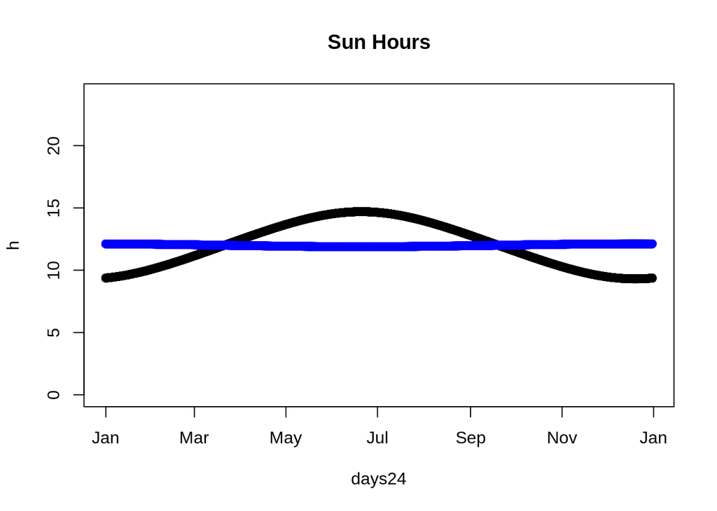

```r
plot(days24, h, main="Sun Hours", ylim = c(0, 24))
points(days24, h2, col="blue")
```

#### First we need to calculate the hour angle, which is based on the distance, in time, from solar noon.

#### Solar noon is only the same as clock noon at intervals of 15 degrees longitude.

#### Hour angles below are relative to solar noon.

#### We can find the associated clock time by shifting t by $(long - nearest 15)/15 * 60$.

#### For Davis longitude = 121.75

#### Define Longitude in Davis, define two times (t and timeline), where t corresponds to the time at 15 degree longitudinal increments, and timeline adjusts to the time at the local longitude.

#### Calculate the hour angle (omega) and replicate phi to make 8760 hours

```r
# Define longitude and find nearest 15 degree interval
longitude = 121.75
hourlongs = seq(0, 360, by = 15)
baselong = hourlongs[abs(hourlongs - longitude) == min(abs(hourlongs - longitude))]

# Define hours at 15 degree intervals (where solar noon and clock noon are the same)
# Make an adjustment based on deviation from 15 degree interval

t = seq(0, 23, by = 1)
m = ((longitude - baselong)/15)*60
if(m<10) {
m = paste0(0, m)
}
tm = paste(t, m, sep=":")
tm365 = rep(tm, 365)

timeline = paste(days24, tm365, sep=" ")
timeline = as.POSIXct(timeline, format = '%F %R')

omega = (12 - t)*360/24
omega365 = rep(omega, 365)

phi8760 = rep(phi, 8760)

p = data.frame(timeline, phi8760, delta, omega365)
```

#### Compute the solar altitude (alpha) and azimuth angle (psi)

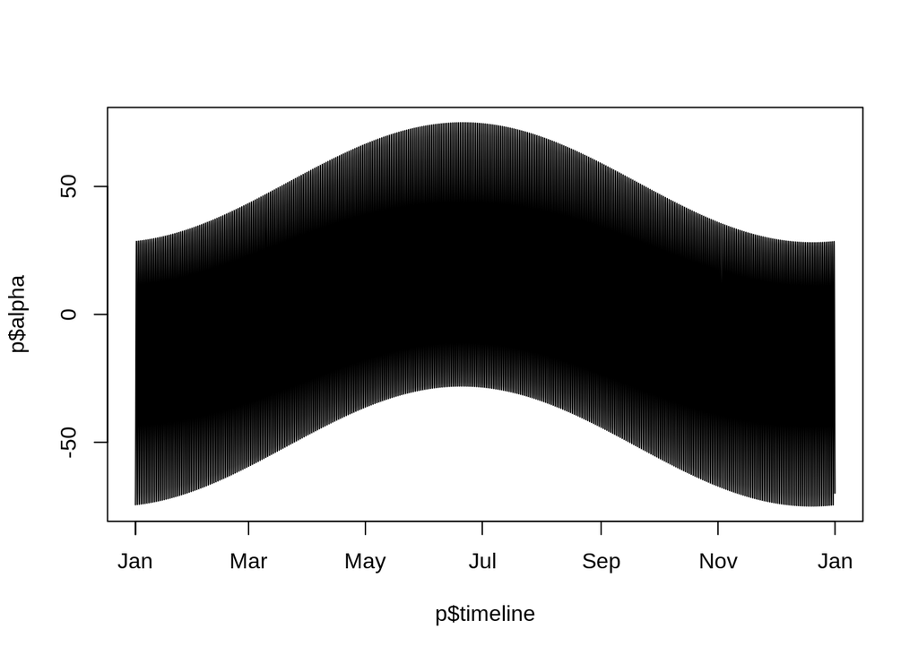

```r
p$alpha = unrad(asin(sin(rad(p$delta))*sin(rad(p$phi8760)) + cos(rad(p$delta))*cos(rad(p$phi8760))*cos(rad(p$omega365))))

plot(p$timeline, p$alpha, type='l')
```

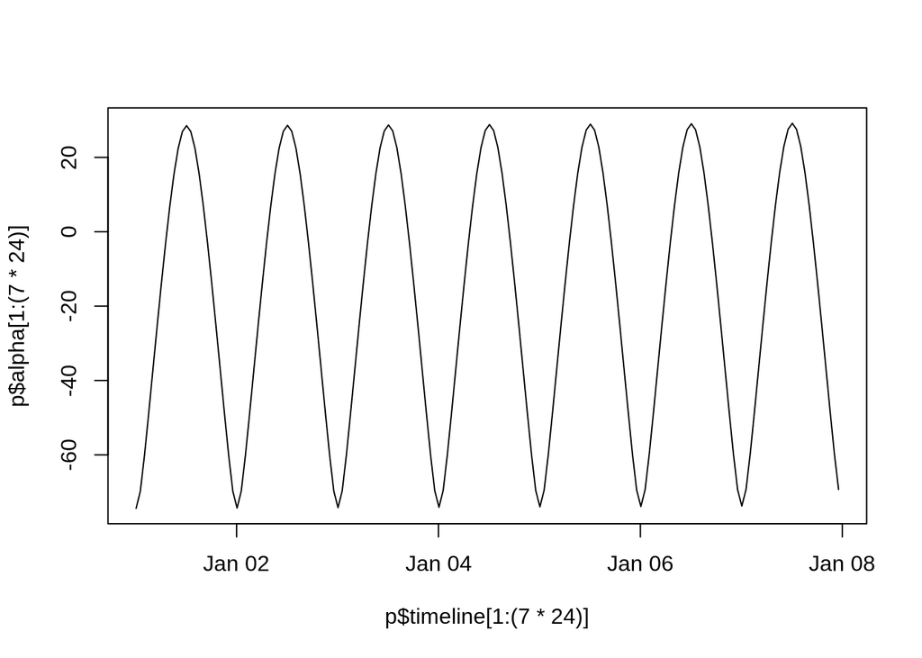

```r
plot(p$timeline[1:(7*24)], p$alpha[1:(7*24)], type='l')
```

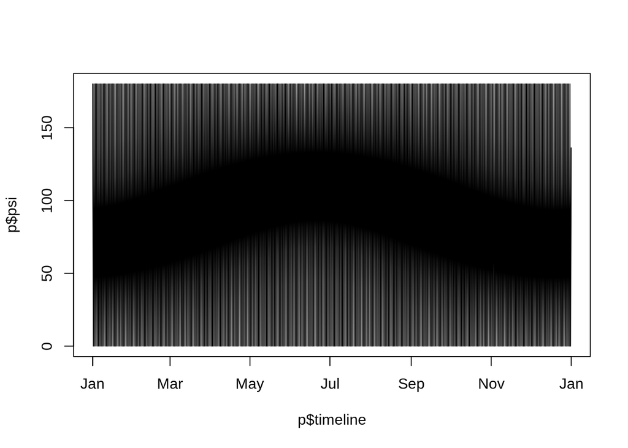

```r
p$psi = unrad(acos( round((sin(rad(p$alpha))*sin(rad(p$phi8760))-sin(rad(p$delta)))/(cos(rad(p$alpha))*cos(rad(p$phi8760))), digits = 6) ))

plot(p$timeline, p$psi, type='l')
```

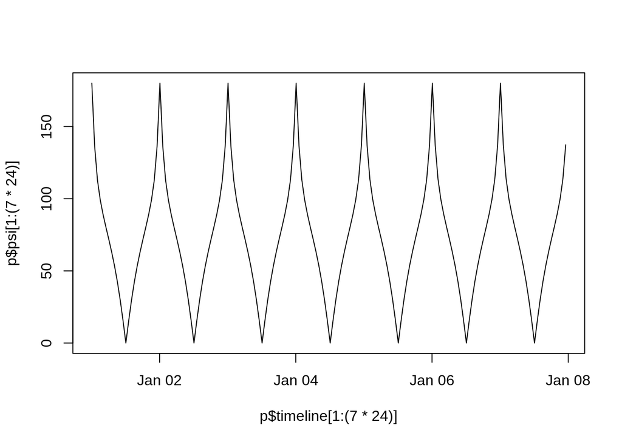

```r
plot(p$timeline[1:(7*24)], p$psi[1:(7*24)], type='l')
```